# NWERN Sampling Analysis

## National Wind Erosion Research Network

1. Background
2. Sampling
   1. Layout
   2. Timeline
3. Pictures of each site

## NWERN Site Summaries

The NWERN was established in 2015, with 11 sites reporting data. NWERN sites represent a range agroecosystems.

**Plot**

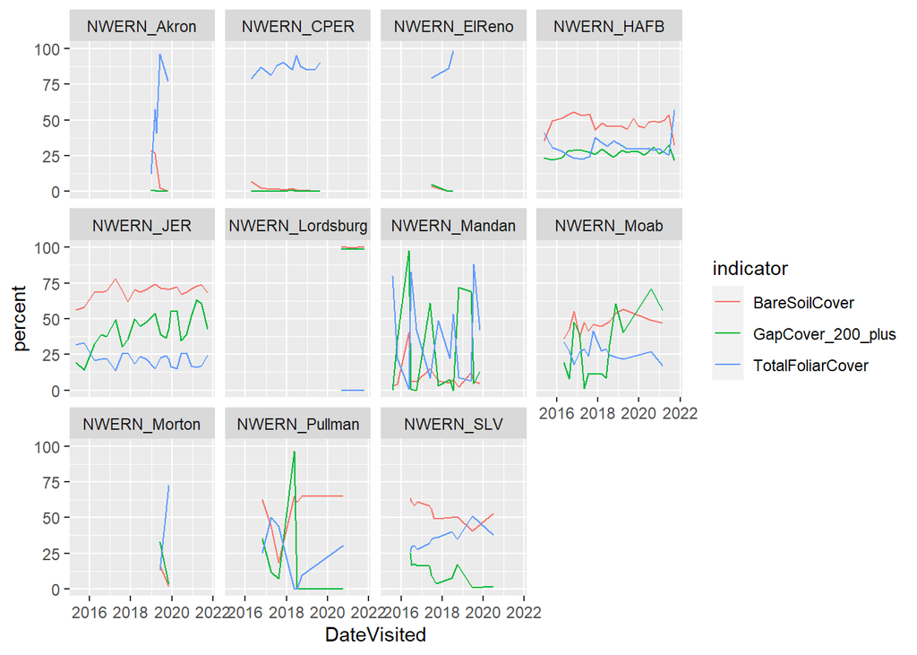

**Visit Summary**

| ProjectKey | n | FirstVisit | LastVisit |
| --- | --- | --- | --- |
| NWERN_Akron | 5 | 2018-12-21 | 2019-10-25 |
| NWERN_CPER | 11 | 2016-04-14 | 2019-08-21 |
| NWERN_ElReno | 3 | 2017-06-19 | 2018-07-17 |
| NWERN_HAFB | 22 | 2015-05-18 | 2021-09-23 |
| NWERN_JER | 23 | 2015-05-05 | 2021-09-22 |
| NWERN_Lordsburg | 5 | 2020-09-02 | 2021-10-14 |
| NWERN_Mandan | 13 | 2015-08-03 | 2019-10-31 |
| NWERN_Moab | 14 | 2016-05-05 | 2021-02-23 |
| NWERN_Morton | 2 | 2019-05-31 | 2019-10-31 |
| NWERN_Pullman | 7 | 2016-10-28 | 2020-10-05 |

[output cut: 1 more lines]

**Indicator Table**

| ProjectKey | PrimaryKey | indicator | mean | sd | max | min |
| --- | --- | --- | --- | --- | --- | --- |
| NWERN_Akron | 19020816041349872018-12-21 | BareSoilCover | 29.05121746 | NA | 29.05121746 | 29.05121746 |
| NWERN_Akron | 19020816041349872018-12-21 | FH_AnnForbCover | 0.00000000 | NA | 0.00000000 | 0.00000000 |
| NWERN_Akron | 19020816041349872018-12-21 | FH_AnnGrassCover | 12.25860621 | NA | 12.25860621 | 12.25860621 |
| NWERN_Akron | 19020816041349872018-12-21 | FH_ForbCover | 0.00000000 | NA | 0.00000000 | 0.00000000 |
| NWERN_Akron | 19020816041349872018-12-21 | FH_GrassCover | 12.25860621 | NA | 12.25860621 | 12.25860621 |
| NWERN_Akron | 19020816041349872018-12-21 | FH_HerbLitterCover | 58.69017632 | NA | 58.69017632 | 58.69017632 |
| NWERN_Akron | 19020816041349872018-12-21 | FH_PerenGrassCover | 0.00000000 | NA | 0.00000000 | 0.00000000 |
| NWERN_Akron | 19020816041349872018-12-21 | FH_RockCover | 0.00000000 | NA | 0.00000000 | 0.00000000 |
| NWERN_Akron | 19020816041349872018-12-21 | FH_TotalLitterCover | 58.69017632 | NA | 58.69017632 | 58.69017632 |
| NWERN_Akron | 19020816041349872018-12-21 | GapCover_101_200 | 2.12000000 | NA | 2.12000000 | 2.12000000 |

[output cut: 1696 more lines]

# NWERN Method Implementation

At each NWERN site, vegetation sampling is conducted at three 100 m transects, which intersect at the center of the site, where a meteorological tower is present (Figure 1). The transects follow the bearings of 0, 60, and 120 degrees respectively. Observations at the center of the site that intersect with the meteorological tower base are removed from analysis.

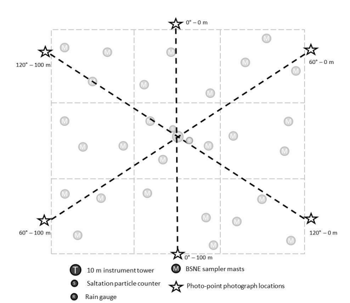

Figure 1. Vegetation sampling transect layout. Note: this illustration is not drawn to scale.

# Line-point Intercept

Currently, LPI pin drops are observed every 25 cm along the vegetation transects. Observations that intersect the meteorological tower pad are removed.

| ProjectKey | mean | min | max |
| --- | --- | --- | --- |
| NWERN_Akron | 1189.400 | 1188 | 1191 |
| NWERN_CPER | 1190.455 | 1187 | 1197 |
| NWERN_ElReno | 1186.000 | 1185 | 1187 |
| NWERN_HAFB | 1185.955 | 1185 | 1187 |
| NWERN_JER | 1186.435 | 1185 | 1188 |
| NWERN_Lordsburg | 1186.800 | 1186 | 1187 |
| NWERN_Mandan | 1186.364 | 1185 | 1189 |
| NWERN_Moab | 1186.643 | 1186 | 1188 |
| NWERN_Morton | 1186.000 | 1186 | 1186 |
| NWERN_Pullman | 1170.143 | 1078 | 1188 |

[output cut: 1 more lines]

1. How many LPI pin drops are needed to get the same answer (within 5%)?
1. How many LPI pin drops are needed to detect 5, 10, 15% change in cover?

# Questions

Look at within site comparison–over time and to full NWERN implementation.

2. How many height measurements are needed to detect a 10% change in height?
3. What is the influence of transect length vs # of pin drops?
4. What is the influence of transect length on gap intercept estimates?
5. Is there a difference in estimates for 3 dispersed transects vs one single transect?